# Marine Ecological Modelling Global Climate Change

Jorge Assis, PhD // Centre of Marine Sciences, University of Algarve

## Ecological Niche Models

## Model fitting

Model fitting is the heart of any SDM application. Many different algorithms are available to fit the relationship between occurrence records and environmental predictors.

### Generalised linear models

Generalised linear model (GLM) is a typical parametric regression algorithm that can fit linear, quadratic or higher polynomial terms and interactions between predictors.

```r
# load a vector defining global landmasses and crop to the Iberia Peninsula extent
world <- shapefile("Data/vectorShapefiles/globalLandmass/world.shp")
IberianExtent <- extent(-15, 5, 25, 46)
iberianLandMass <- crop(world, IberianExtent)

# read presence / absence datasets for an intertidal species
absences <- read.csv("Data/dataBases/Kelp-monitoring-absent.csv", sep = ";")
presences <- read.csv("Data/dataBases/Kelp-monitoring-presence.csv", sep = ";")
```

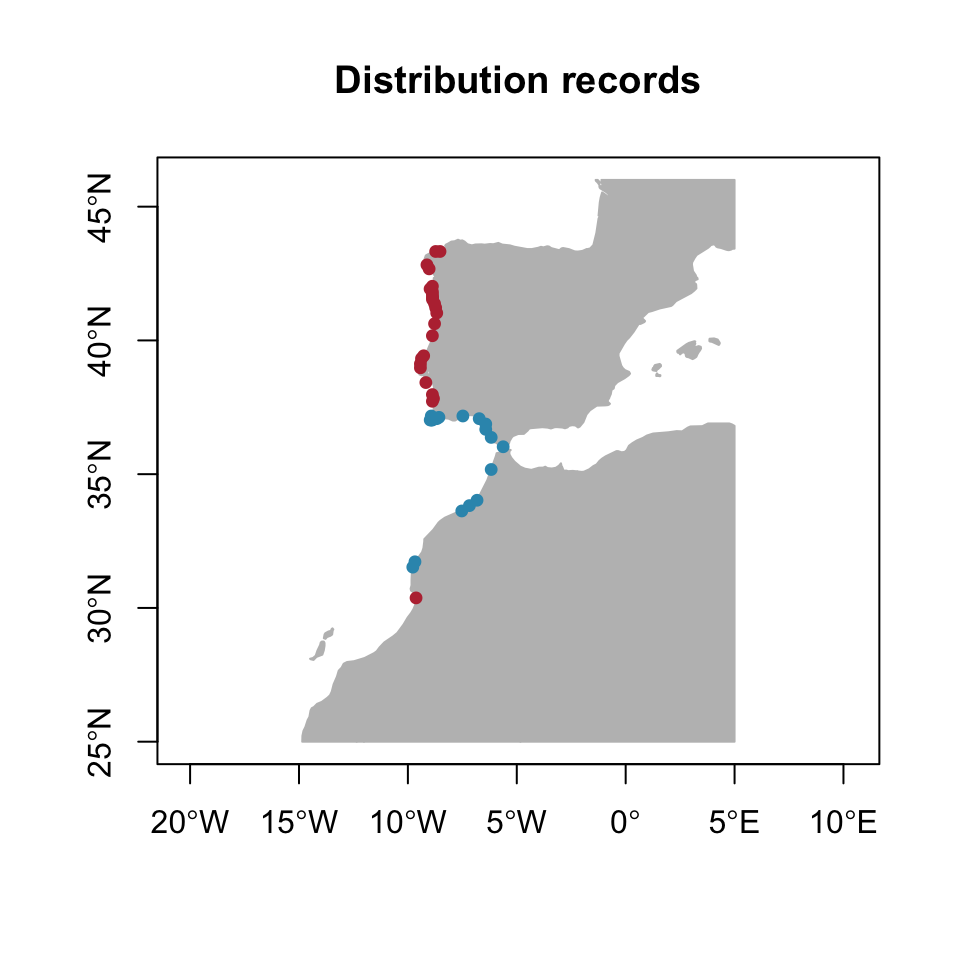

```r
# plot the distribution of records
plot(iberianLandMass, col = "gray", border = "gray", main = "Distribution records", axes = TRUE)
points(absences, add = TRUE, cex = 0.75, pch = 19, col = "#3296BA")
points(presences, add = TRUE, cex = 0.75, pch = 19, col = "#BA323F")
```

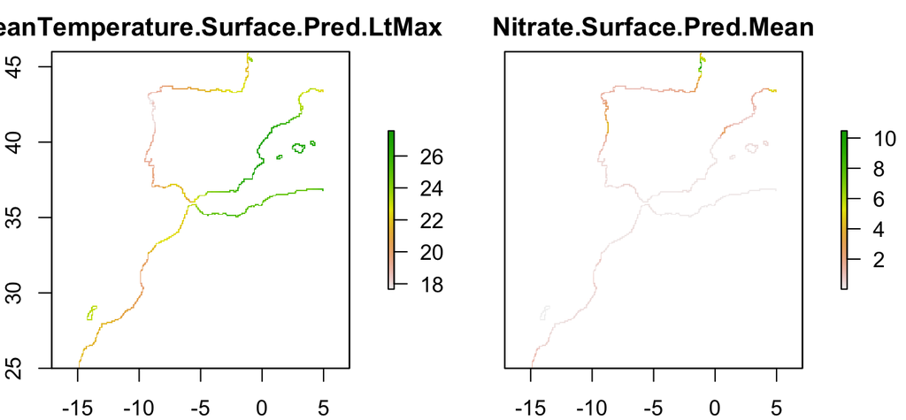

```r
# get raster layers and stack into a unique object
temMax <- raster("Data/rasterLayers/Climate/Present/OceanTemperature Surface Pred LtMax.tif")
nutrients <- raster("Data/rasterLayers/Climate/Present/Nitrate Surface Pred Mean.tif")
envConditions <- stack(temMax, nutrients)

# mask rasters to coastline regions (intertidal species) and crop to the region of interest
coastline <- raster("Data/rasterLayers/CoastLine.tif")
envConditions <- mask(envConditions, coastline)
envConditions <- crop(envConditions, IberianExtent)
plot(envConditions)
```

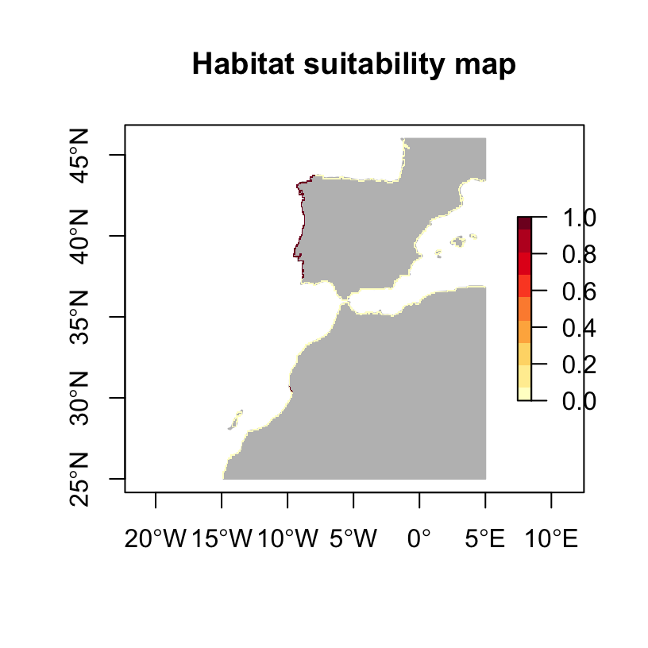

```r
# extract environmental values and make an object with all information to model
modelData <- prepareModelData(presences, absences, envConditions)

# fit a binomial GLM to the dataset
model <- trainGLM(modelData)

# predict and map the distribution with the GLM over a raster stack
map <- predict(envConditions, model, type = "response")
plot(iberianLandMass, col = "gray", border = "gray", main = "Habitat suitability map", axes = TRUE)
plot(map, col = brewer.pal(n = 11, name = "YlOrRd"), add = TRUE)
```

### Pseudo-absence data

If true absence data is not available, but one wants to fit an ecological niche model, pseudo-absence data can be generated.

```r
# generate pseudo-absences
pAbsences <- pseudoAbsences(envConditions, presences, n = 100)
head(pAbsences)
```

```
##             Lon      Lat
## 820 -10.0416667 29.70833
## 833 -13.7916667 29.12500
## 205   3.2083333 41.95833
## 262   0.2916667 40.20833
## 662  -3.9583333 35.29167
## 386  -0.7916667 37.79167
```

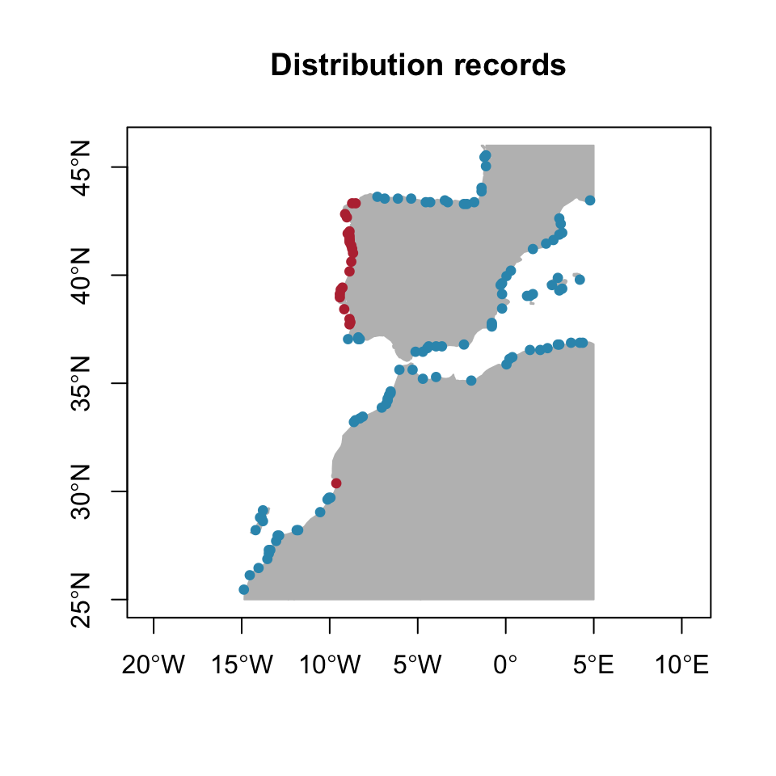

```r
# plot presences and pseudo-absences
plot(iberianLandMass, col = "gray", border = "gray", main = "Distribution records", axes = TRUE)
points(pAbsences, add = TRUE, cex = 0.75, pch = 19, col = "#3296BA")
points(presences, add = TRUE, cex = 0.75, pch = 19, col = "#BA323F")
```

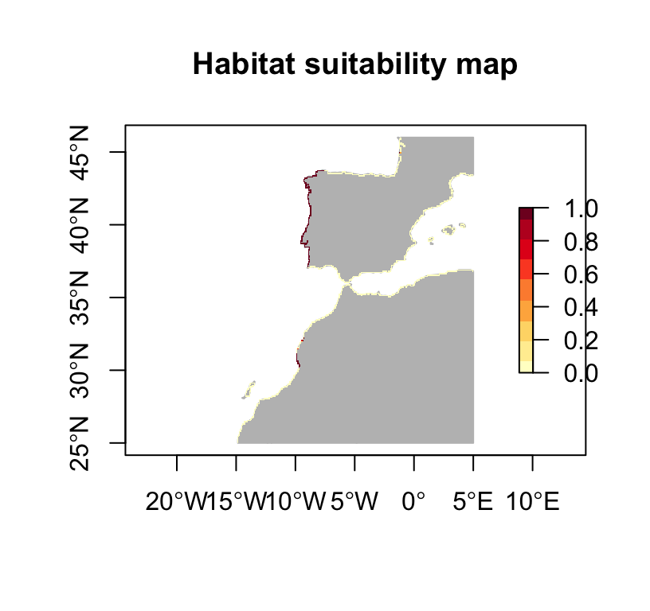

```r
# extract environmental values and make an object with all information to model
modelData <- prepareModelData(presences, pAbsences, envConditions)

# fit a binomial GLM to the dataset
model <- trainGLM(modelData)

# predict and map the distribution with the GLM over a raster stack
map <- predict(envConditions, model, type = "response")
plot(iberianLandMass, col = "gray", border = "gray", main = "Habitat suitability map", axes = TRUE)
plot(map, col = brewer.pal(n = 11, name = "YlOrRd"), add = TRUE)
```

### Maximum Entropy

Maxent only uses presence data and the algorithm compares the locations of where a species has been found to all the environments that are available in the study region.

```r
# load a presence dataset of a Mediterranean coral
presences <- read.csv("Data/dataBases/Paramuricea_clavata.csv", sep = ";")
presences <- presences[, c("Lon", "Lat")]

# load layers of temperatures, oxygen and productivity
tempMin <- raster("Data/rasterLayers/Climate/Present/OceanTemperature Benthic Mean Pred LtMin.tif")
tempMax <- raster("Data/rasterLayers/Climate/Present/OceanTemperature Benthic Mean Pred LtMax.tif")
oxygen <- raster("Data/rasterLayers/Climate/Present/DissolvedMolecularOxygen Benthic Mean Pred Mean.tif")
productivity <- raster("Data/rasterLayers/Climate/Present/TotalPrimaryProductionPhyto Benthic Mean Pred Mean.tif")

# stack layers to generate a unique object
envConditionsPresent <- stack(tempMin, tempMax, oxygen, productivity)

# rename layers for simplicity
names(envConditionsPresent) <- c("tempMin", "tempMax", "oxygen", "productivity")
```

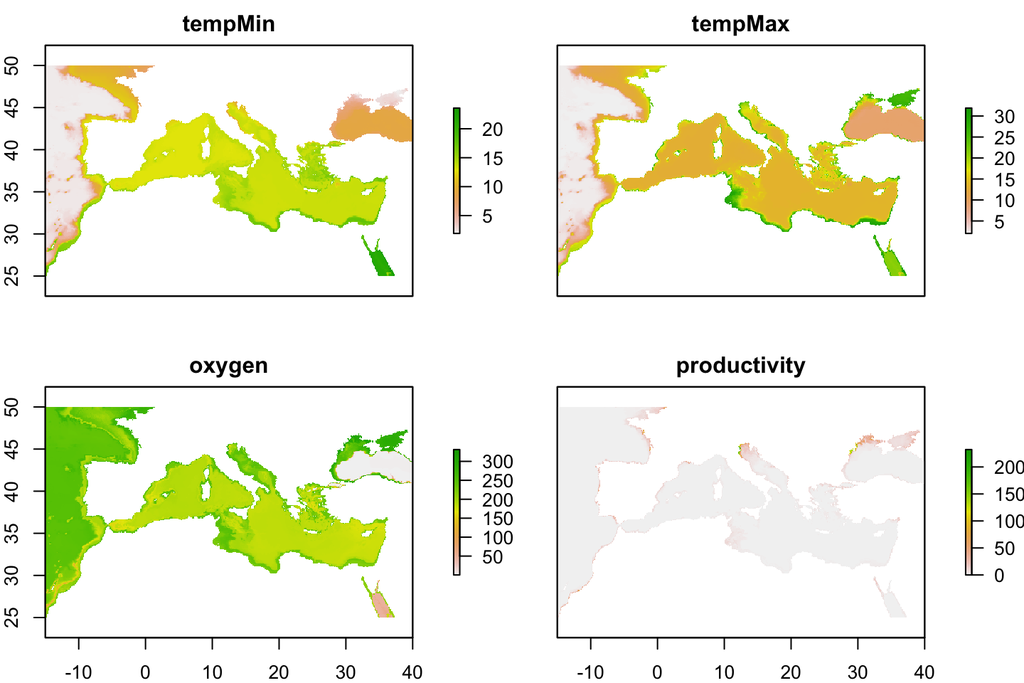

```r
# crop layers to the European extent and plot
europeanExtent <- extent(-15, 40, 25, 50)
envConditionsPresent <- crop(envConditionsPresent, europeanExtent)
plot(envConditionsPresent)
```

```r
# generate background information
background <- backgroundInformation(envConditionsPresent, n = 10000)

# extract environmental values and make a data.frame with PA information
modelData <- prepareModelData(presences, background, envConditionsPresent)

# fit a Maxent model to the dataset
model <- train("Maxnet", modelData)

# predict with Maxent to raster stack
mapPresent <- predict(model, envConditionsPresent, type = "logistic")
```

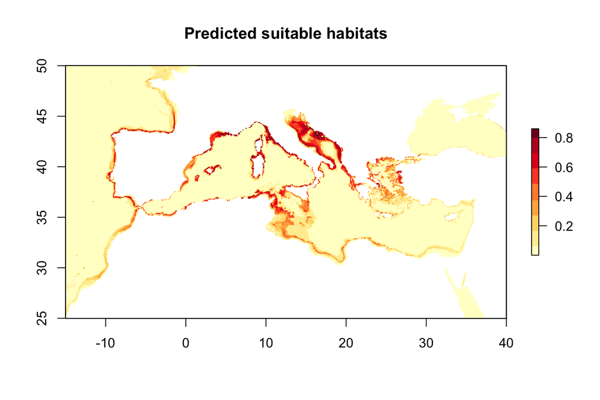

```r
# plot prediction of suitable habitats
plot(mapPresent, col = brewer.pal(n = 11, name = "YlOrRd"), main = "Predicted suitable habitats")
```

### Challenge 4.1

The main objetive of this challenge is to **fit** a MaxEnt model to your own occurrence and environmental data.

**Packages, data and functions to accomplish the challenge:**

Go to Menu -> Sessions -> Set the working directory -> My directory of Sessions_[P]  
Run: source(“sourceFunctions.R”)  
Files to use:  
(…)  
Functions to use:  
raster(), stack(), extent() & crop()  
backgroundInformation(), prepareModelData(), train() & predict()  
plot()

## Model transferability

Model transferability is the process of transferring a model to a new dataset.

### Temporal transferability

Temporal transferability is the task of predicting to a distinct time than where the model was trained.

```r
# load layers of temperatures, oxygen and productivity
tempMin <- raster("Data/rasterLayers/Climate/RCP85/OceanTemperature Benthic Mean Pred LtMin.tif")
tempMax <- raster("Data/rasterLayers/Climate/RCP85/OceanTemperature Benthic Mean Pred LtMax.tif")
oxygen <- raster("Data/rasterLayers/Climate/RCP85/DissolvedMolecularOxygen Benthic Mean Pred Mean.tif")
productivity <- raster("Data/rasterLayers/Climate/RCP85/TotalPrimaryProductionPhyto Benthic Mean Pred Mean.tif")

# stack layers to generate a unique object and rename
envConditionsFuture <- stack(tempMin, tempMax, oxygen, productivity)
```

Predictor layers must have the same name for proper transferability.

```r
# compare layer names
names(envConditionsPresent)
```

```
## [1] "tempMin"      "tempMax"      "oxygen"       "productivity"
```

```r
names(envConditionsFuture)
```

```
## [1] "OceanTemperature.Benthic.Mean.Pred.LtMin"
## [2] "OceanTemperature.Benthic.Mean.Pred.LtMax"
## [3] "DissolvedMolecularOxygen.Benthic.Mean.Pred.Mean"
## [4] "TotalPrimaryProductionPhyto.Benthic.Mean.Pred.Mean"
```

```r
# change layer names for them to match
names(envConditionsFuture) <- c("tempMin", "tempMax", "oxygen", "productivity")

# crop layers to the European extent
envConditionsFuture <- crop(envConditionsFuture, europeanExtent)
```

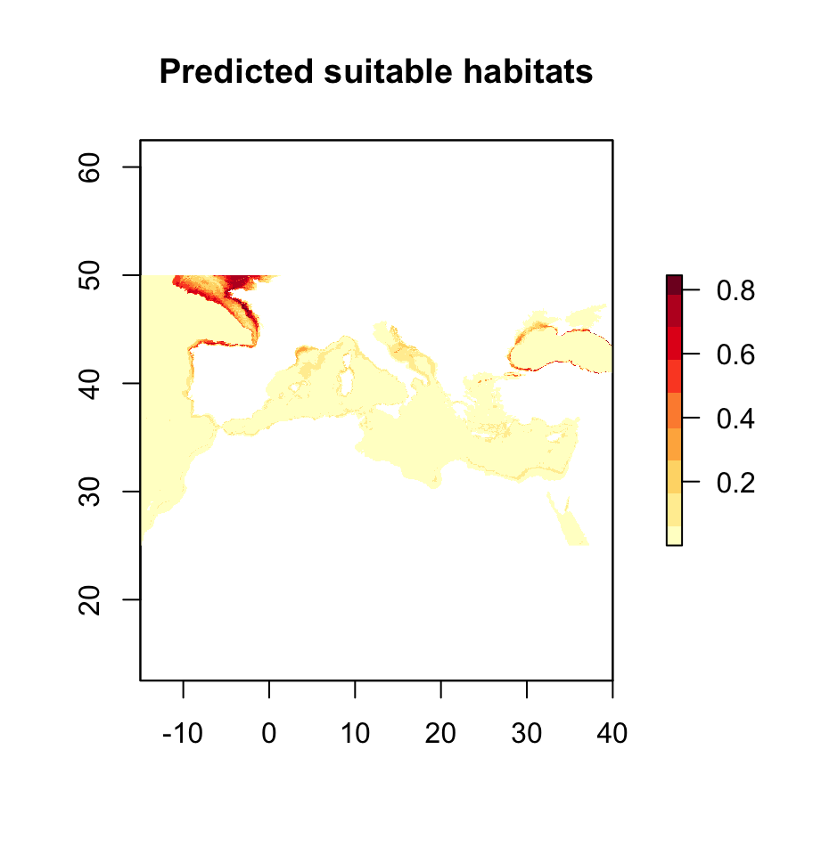

```r
# predict an map with Maxent for a differenttime period
mapRCP85 <- predict(model, envConditionsFuture, type = c("logistic"))
plot(mapRCP85, col = brewer.pal(n = 11, name = "YlOrRd"), main = "Predicted suitable habitats")
```

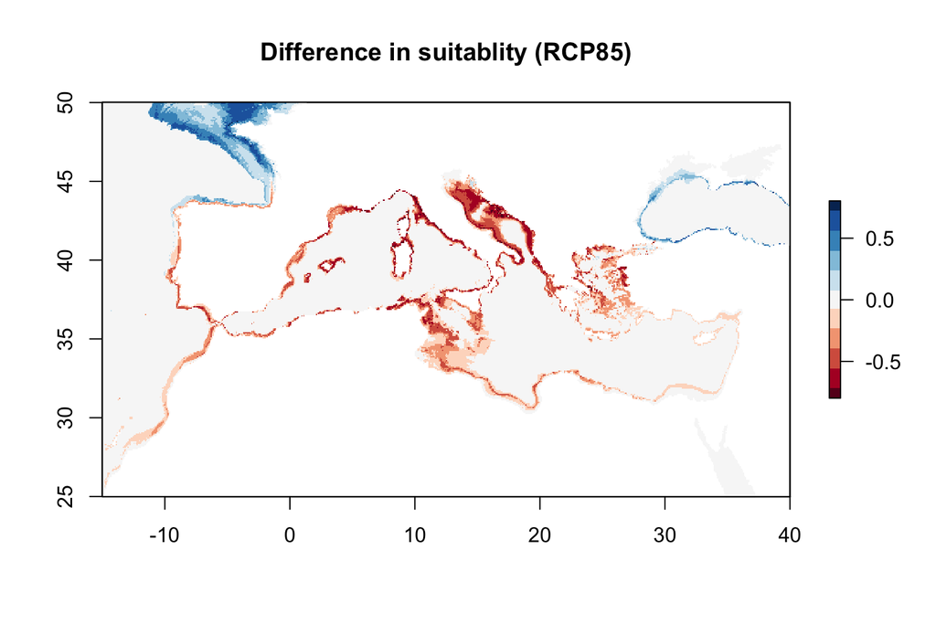

```r
# plot difference in habitat suitability
diffRCP85 <- mapRCP85 - mapPresent
plot(diffRCP85, main = "Difference in suitablity (RCP85)", col = brewer.pal(n = 11, name = "RdBu"))
```

### Challenge 4.2

The main objetive of this challenge is to **fit** a MaxEnt model to your own occurrence and environmental data and transfer the model to different climate conditions.

**Packages, data and functions to accomplish the challenge:**

Go to Menu -> Sessions -> Set the working directory -> My directory of Sessions_[P]  
Run: source(“sourceFunctions.R”)  
Files to use:  
(…)  
Functions to use:  
raster(), stack(), extent() & crop()  
backgroundInformation(), prepareModelData(), train() & predict()  
plot()

### Spatial transferability

Spatial transferability is the task of predicting to a distinct region than where the model was trained.

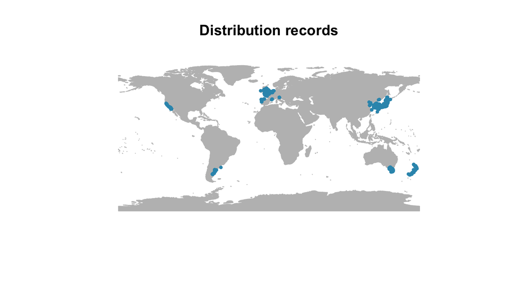

```r
# load a presence dataset for an invasive species
presences <- getOccurrencesGBIF("Undaria pinnatifida")
presences <- presences[, c("Lon", "Lat")]

# plot the distribution of records
plot(world, col = "gray", border = "gray", main = "Distribution records")
points(presences, add = TRUE, cex = 0.5, pch = 19, col = "#3296BA")
```

### Spatial transferability

Spatial transferability is the task of predicting to a distinct region than where the model was trained.

```r
# Open and stack raster layers
tempMin <- raster("Data/rasterLayers/Climate/Present/OceanTemperature Benthic Mean Pred LtMin.tif")
tempMax <- raster("Data/rasterLayers/Climate/Present/OceanTemperature Benthic Mean Pred LtMax.tif")
nitrate <- raster("Data/rasterLayers/Climate/Present/Nitrate Surface Pred Mean.tif")
envConditionsPresent <- stack(tempMin, tempMax, nitrate)

# mask layers to the coastal region, and then rename
coastline <- raster("Data/rasterLayers/CoastLine.tif")
envConditionsPresent <- mask(envConditionsPresent, coastline)
names(envConditionsPresent) <- c("tempMin", "tempMax", "Nitrate")
```

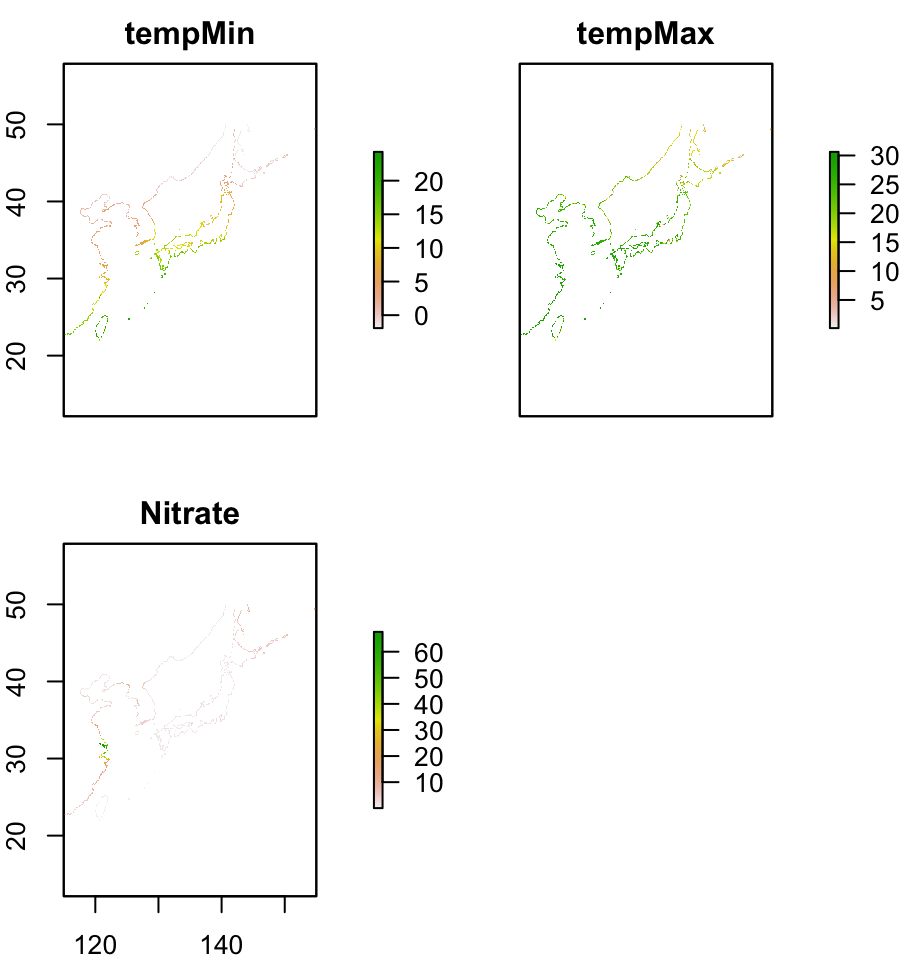

```r
# crop and plot layers to the native extent
nativeExtent <- extent(115, 155, 20, 50)
envConditionsPresentNative <- crop(envConditionsPresent, nativeExtent)
plot(envConditionsPresentNative)
```

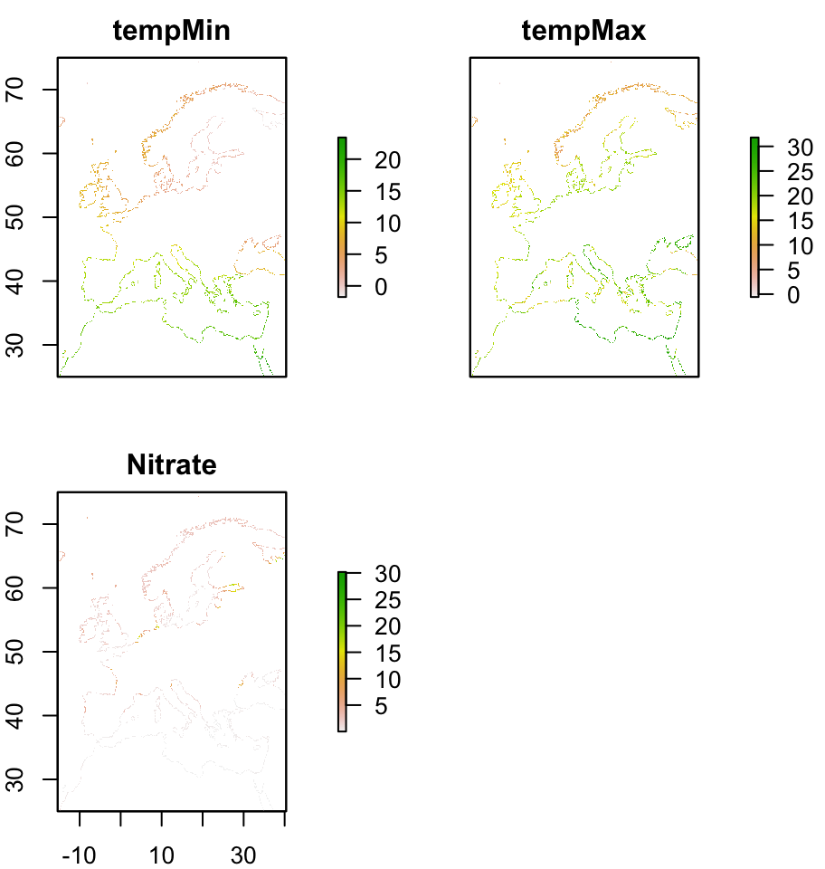

```r
# crop layers to the Invasive European extent
europeanExtent <- extent(-15, 40, 25, 75)
envConditionsPresentInvasive <- crop(envConditionsPresent, europeanExtent)
plot(envConditionsPresentInvasive)
```

```r
# generate background information
background <- backgroundInformation(envConditionsPresentNative, n = 10000)

# extract environmental values and make a data.frame with PA information
modelData <- prepareModelData(presences, background, envConditionsPresentNative)

# fit a Maxent model to the dataset
model <- train("Maxnet", modelData, folds = NULL)

# predict with Maxent to the different regions
mapNative <- predict(model, envConditionsPresentNative, type = c("logistic"))
mapEurope <- predict(model, envConditionsPresentInvasive, type = c("logistic"))
```

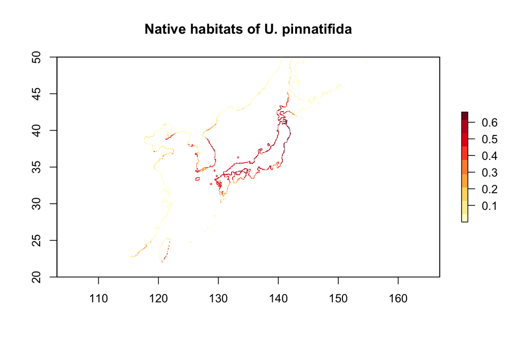

```r
# plot suitable habitats for native extent
plot(mapNative, main = "Native habitats of U. pinnatifida", col = brewer.pal(n = 11, name = "YlOrRd"))
```

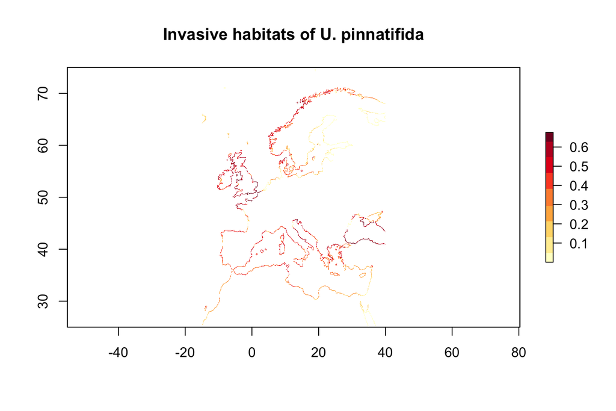

```r
# plot suitable habitats for invasive extent
plot(mapEurope, main = "Invasive habitats of U. pinnatifida", col = brewer.pal(n = 11, name = "YlOrRd"))
```

### Challenge 4.3

The main objetive of this challenge is to **fit** a MaxEnt model to your own occurrence and environmental data and transfer the model to a different geographic regions

**Packages, data and functions to accomplish the challenge:**

Go to Menu -> Sessions -> Set the working directory -> My directory of Sessions_[P]  
Run: source(“sourceFunctions.R”)  
Files to use:  
(…)  
Functions to use:  
raster(), stack(), extent() & crop()  
backgroundInformation(), prepareModelData(), train() & predict()  
plot()

## References

Global change impacts on biodiversity. Available at: https://damariszurell.github.io/HU-GCIB

Copyright (c) Earth Lab. Available at: https://www.earthdatascience.org.

Open Science for Synthesis: Gulf Research Program Workshop. Available at: https://github.com/NCEAS/oss-lessons

Gimond, M. (2019) Intro to GIS and Spatial Analysis. Available at: https://mgimond.github.io/Spatial/